# Final

```python
#
import rasterio
import geopandas as gpd
import numpy as np
import matplotlib.pyplot as plt
import requests
import json
import datetime
import pandas as pd


from pprint import pprint
from rasterio.features import Window
from rasterio.windows import bounds
from shapely.geometry import MultiPolygon, box
from PIL import Image
from rasterio.features import Window
from subprocess import call
from IPython import display

# reminder that if you are installing libraries in a Google Colab instance you will be prompted to restart your kernal
import seaborn as sns

import statsmodels.api as sm
from scipy import stats
import plotly.offline as py
import plotly.graph_objs as go

from ipyleaflet import GeoJSON
from geemap import geojson_to_ee, ee_to_geojson

#Map = geemap.Map()
#ee_data = geojson_to_ee('./data/planet_22.6586,39.256_23.2218,39.4689.geojson')
#Map.addLayer(ee_data, {}, "Volos")
```

```python
try:
    import geemap, ee
except ModuleNotFoundError:
    if 'google.colab' in str(get_ipython()):
        print("package not found, installing w/ pip in Google Colab...")
        !pip install geemap
    else:
        print("package not found, installing w/ conda...")
        !conda install mamba -c conda-forge -y
        !mamba install geemap -c conda-forge -y
    import geemap, ee
```

```python
import panel as pn
pn.extension(comms='ipywidgets')
```

```python
try:
        ee.Initialize()
except Exception as e:
        ee.Authenticate()
        ee.Initialize()
```

### Specify some areas of interest manually

In the near future I'll create a function that uses the greece geopackage so that the user can test with that as well.

```python
#this could also be done with a function, but I should provide a list with available names
greece_gdf = gpd.read_file("./data/kontur_boundaries_GR_20220407.gpkg") #read greece geopackage
volos_gdf = greece_gdf[greece_gdf['name_en']=='Volos Municipality'] # select shapefile only for volos
#countries_fc = geemap.geopandas_to_ee(countries_gdf)
volos_fc = geemap.geopandas_to_ee(volos_gdf) #make feature collection for volos
trikala_mun_gdf = greece_gdf[greece_gdf['name_en']=='Trikala Municipality'] #Trikala Municipality shapefile
trikala_regunit_gdf = greece_gdf[greece_gdf['name_en']=='Trikala Regional Unit'] #Trikala Regional Unit shapefile

trikala_mun_fc = geemap.geopandas_to_ee(trikala_mun_gdf) #make feature collection for trikala municipality
trikala_regun_fc = geemap.geopandas_to_ee(trikala_regunit_gdf) #make feature collection for trikala regional unit
```

### User Input Fuctions

User specifies desired date and area of interest

```python
# See google earth datasets for data availability over a particular datetime

#Latest Sentinel-2: 2017-03-28T00:00:00Z - 2022-06-10T00:00:00
#latest Viirs DNB Monthly : 2014-01-01T00:00:00Z - 2022-05-01T00:00:00
```

```python
#function that takes desired timeframe through user input ini YY-MM-DD format\n",
def set_dates():
    startDate = input('Enter you desired starting date (YYYYMMDD): ')
    endDate = input('Enter you desired ending date (YYYYMMDD): ')
    return startDate,endDate

startDate,endDate= set_dates()
#('2015-01-01','2022-01-01')
```

```
Enter you desired starting date (YYYYMMDD): 2020-01-01
Enter you desired ending date (YYYYMMDD): 2022-05-01
```

```python
#2021-01-01 2022-01-01
```

```python
### Data, preprocessing and visualization
```

```python
# get our Magnisia boundary - there's a problem with the coastline
magnisia = ee.FeatureCollection("FAO/GAUL/2015/level2").filter(ee.Filter.eq('ADM2_NAME','Magnisias')).geometry()
```

```python
trikala = ee.FeatureCollection("FAO/GAUL/2015/level2").filter(ee.Filter.eq('ADM2_NAME','Trikkaion')).geometry()
```

```python
# Get data from GGE over the specified location and timeframe
```

# try with a rough outline of volos municipality volos_rough = ee.Geometry.Polygon([ [ 22.96614646911621, 39.35095850174936 ], [ 22.996315956115723, 39.373454601030474 ], [ 22.971510887145996, 39.391499329244546 ], [ 22.951598167419434, 39.38901182227906 ], [ 22.94391632080078, 39.41219194887819 ], [ 22.92245864868164, 39.41232457407302 ], [ 22.914047241210938, 39.39388725250263 ], [ 22.916278839111325, 39.38738660316804 ], [ 22.903404235839844, 39.37425079034718 ], [ 22.893447875976562, 39.359519818280745 ], [ 22.925891876220703, 39.35155583694641 ], [ 22.932758331298828, 39.35474153842095 ], [ 22.96794891357422, 39.35089213085671 ] ])

```python
import time
from datetime import timedelta
```

```python
import eemont #improved iteration of ee api

# construct a feature collection using two topologies with a radius of 50meters each, they probably overlap
# this was improved later, where I added hand-labeled locations(abandoned/not abandoned buildings)
#f1 = ee.Feature(ee.Geometry.Point([22.951893210411072,39.35932487749404]).buffer(50),{'ID':'A'})
#f2 = ee.Feature(ee.Geometry.Point([22.947140336036682,39.36547976654773]).buffer(50),{'ID':'B'})
#fc = ee.FeatureCollection([volos_rough])

#data from sentinel-2 surface reflectance

s2 = (ee.ImageCollection("COPERNICUS/S2_SR")
    .filterBounds(magnisia)
    .filterDate(startDate,endDate)
    .maskClouds()
    #.scaleAndOffset()
    .spectralIndices(['EVI','NDVI','NDBI','IBI','UI','BLFEI']))

#select some bands
#N = s2.select('B8')
#R = s2.select('B4')
#B = s2.select('B2')
#G = s2.select('B3')
print('done')
```

```
done
```

```python
#generate time series over aoi, get spectral indices(awsome index)

s2_ts = s2.getTimeSeriesByRegion(ee.Reducer.mean(),
                              geometry = volos_fc,
                              bands = ['NDVI','NDBI','IBI','UI'],
                              scale = 10,
                              bestEffort = True,
                              maxPixels = 1e13,
                              dateFormat = 'YYYYMMdd',
                              tileScale = 2)
start_time = time.monotonic()

#use geemap to generate a pandas dataframe from the time series(contains the ts for the selected indices)
s2_df= geemap.ee_to_pandas(s2_ts)
end_time = time.monotonic()
print(timedelta(seconds=end_time - start_time))
s2_df[s2_df == -9999] = np.nan # we do that to generate nan values when we don't have data
s2_df['date'] = pd.to_datetime(s2_df['date'],infer_datetime_format = True)
```

```
0:00:28.328000
```

```python
# preview the sentinel-2 time series dataframe
s2_df
```

|  | reducer | date | NDVI | NDBI | IBI | UI |
| --- | --- | --- | --- | --- | --- | --- |
| 0 | mean | 2020-01-04 | 0.549254 | -0.231373 | -1.775703 | -0.429414 |
| 1 | mean | 2020-01-04 | NaN | NaN | NaN | NaN |
| 2 | mean | 2020-01-04 | NaN | NaN | NaN | NaN |
| 3 | mean | 2020-01-06 | 0.695607 | -0.412036 | -6.752086 | -0.588348 |
| 4 | mean | 2020-01-06 | NaN | NaN | NaN | NaN |
| ... | ... | ... | ... | ... | ... | ... |
| 1014 | mean | 2022-04-28 | NaN | NaN | NaN | NaN |
| 1015 | mean | 2022-04-28 | NaN | NaN | NaN | NaN |
| 1016 | mean | 2022-04-30 | 0.315161 | -0.233853 | -8.190977 | -0.407168 |
| 1017 | mean | 2022-04-30 | NaN | NaN | NaN | NaN |
| 1018 | mean | 2022-04-30 | NaN | NaN | NaN | NaN |

1019 rows × 6 columns

```python
#get times series of average radiance from viirs dnb monthly composites
viirs = ee.ImageCollection("NOAA/VIIRS/DNB/MONTHLY_V1/VCMSLCFG").filterDate(startDate,endDate).select('avg_rad')

viirs_ts = viirs.getTimeSeriesByRegion(ee.Reducer.mean(),
                              geometry = volos_fc,
                              scale = 10,
                              bestEffort = True,
                              maxPixels = 2e9,
                              dateFormat = 'YYYYMMdd',
                              tileScale = 2)

viirs_df = geemap.ee_to_pandas(viirs_ts)
viirs_df['date'] = pd.to_datetime(viirs_df['date'],infer_datetime_format = True)
```

```python
viirs_df
```

|  | reducer | date | avg_rad |
| --- | --- | --- | --- |
| 0 | mean | 2020-01-01 | 4.675772 |
| 1 | mean | 2020-02-01 | 4.692925 |
| 2 | mean | 2020-03-01 | 4.352947 |
| 3 | mean | 2020-04-01 | 4.783422 |
| 4 | mean | 2020-05-01 | 4.536045 |
| 5 | mean | 2020-06-01 | 4.577717 |
| 6 | mean | 2020-07-01 | 4.449237 |
| 7 | mean | 2020-08-01 | 4.539433 |
| 8 | mean | 2020-09-01 | 4.442848 |
| 9 | mean | 2020-10-01 | 5.170358 |
| 10 | mean | 2020-11-01 | 4.526725 |
| 11 | mean | 2020-12-01 | 4.377061 |
| 12 | mean | 2021-01-01 | 4.748482 |
| 13 | mean | 2021-02-01 | 5.666021 |
| 14 | mean | 2021-03-01 | 5.804959 |
| 15 | mean | 2021-04-01 | 5.735382 |
| 16 | mean | 2021-05-01 | 6.051599 |
| 17 | mean | 2021-06-01 | 5.547343 |
| 18 | mean | 2021-07-01 | 5.462366 |
| 19 | mean | 2021-08-01 | 5.467300 |
| 20 | mean | 2021-09-01 | 5.535593 |
| 21 | mean | 2021-10-01 | 5.322791 |
| 22 | mean | 2021-11-01 | 4.665055 |
| 23 | mean | 2021-12-01 | 5.529470 |
| 24 | mean | 2022-01-01 | 6.146584 |
| 25 | mean | 2022-02-01 | 6.270673 |
| 26 | mean | 2022-03-01 | 5.708471 |
| 27 | mean | 2022-04-01 | 6.230568 |

```python
#enter integet for desired image number
image_no = int(input())
```

```
0
```

```python
type(image_no)
```

```
int
```

```python
#function that takes as input the desired collections and returns the image we want
def make_list_of_images(sentinel_collection,viirs_collection,image_no):
    listOfS2Images = sentinel_collection.toList(sentinel_collection.size())
    s2img = ee.Image(listOfS2Images.get(image_no))
    listOfViirsImages= viirs_collection.toList(viirs_collection.size())
    viirs_img = ee.Image(listOfViirsImages.get(image_no))
    return s2img,viirs_img
s2img,viirs_img = make_list_of_images(s2,viirs,image_no)
```

```python
# We proceed to visuzlize our aoi on a Map
# We use the geemap tool, since it integrates with gee and offers some cool features, such as timelapse
# and even geoprocessing tools
```

```python
# initialize our map
Map = geemap.Map()
Map.centerObject(volos_fc, 7)
Map.addLayer(s2img.clip(magnisia), rgbViz, "S2")
Map.addLayer(viirs_img.clip(magnisia), {}, "Viirs")
Map.addLayerControl()
Map
```

### Data Preprocessing

In this part of the notebook, I ll do some basic preprocessing in order to better visualize the data. Some extra preprocessing may be added in the future.

Implemented :

```
- Fill each column with the mean values
```

Will be added :

```
- Fill with interpolation
- Harmonizing
```

```python
# This should be turned into a function, in which you can specify the fill method(mean,mode,median)
```

```python
filled_sentinel = pd.DataFrame()
filled_sentinel['date'] = s2_df['date']
```

```python
#filled_sentinel['EVI'] = s2_df['EVI'].fillna(s2_df['EVI'].mean())
filled_sentinel['NDVI'] = s2_df['NDVI'].fillna(s2_df['NDVI'].mean())
filled_sentinel['IBI'] = s2_df['IBI'].fillna(s2_df['IBI'].mean())
filled_sentinel['NDBI'] = s2_df['NDBI'].fillna(s2_df['NDBI'].mean())
#filled_sentinel['BLFEI'] = s2_df['BLFEI'].fillna(s2_df['BLFEI'].mean())
filled_sentinel['UI'] = s2_df['UI'].fillna(s2_df['UI'].mean())
```

```python
filled_sentinel # to evi exei 100% outlier, genika kalo tha htan na vrw tous outliers prin kanw kapoio fillna me mean giati
                # einai euais8hto
```

|  | date | NDVI | IBI | NDBI | UI |
| --- | --- | --- | --- | --- | --- |
| 0 | 2020-01-04 | 0.549254 | -1.775703e+00 | -0.231373 | -0.429414 |
| 1 | 2020-01-04 | 0.467781 | -4.107221e+07 | -0.187610 | -0.366849 |
| 2 | 2020-01-04 | 0.467781 | -4.107221e+07 | -0.187610 | -0.366849 |
| 3 | 2020-01-06 | 0.695607 | -6.752086e+00 | -0.412036 | -0.588348 |
| 4 | 2020-01-06 | 0.467781 | -4.107221e+07 | -0.187610 | -0.366849 |
| ... | ... | ... | ... | ... | ... |
| 1014 | 2022-04-28 | 0.467781 | -4.107221e+07 | -0.187610 | -0.366849 |
| 1015 | 2022-04-28 | 0.467781 | -4.107221e+07 | -0.187610 | -0.366849 |
| 1016 | 2022-04-30 | 0.315161 | -8.190977e+00 | -0.233853 | -0.407168 |
| 1017 | 2022-04-30 | 0.467781 | -4.107221e+07 | -0.187610 | -0.366849 |
| 1018 | 2022-04-30 | 0.467781 | -4.107221e+07 | -0.187610 | -0.366849 |

1019 rows × 5 columns

```python
# Save dataframes to csv in order to perform EDA in other notebooks
```

```python
filled_sentinel.to_csv('./data/csvs/filled_sentinel.csv',index=False)
viirs_df.to_csv('./data/csvs/viirs.csv',index=False)
```

# Function to fill each column with mean #s2_df.columns def fill_nan(data): for i in data.columns: filled[i] = data[i].fillna(data[i].mean(),inplace=True) return filled mean_filled = fill_nan(s2_df) mean_filled.isnull().sum()

# Data Visualization

```python
#After getting a better feel of our aoi we can now create some plots
```

https://udst.github.io/urbansim/examples.html

```python
#function to create plots
```

```python
from ipywidgets import widgets, interactive
```

```python
from matplotlib.figure import Figure
from matplotlib.backends.backend_agg import FigureCanvas



def mpl_plot(avg, highlight):
    fig = Figure()
    FigureCanvas(fig) # not needed in mpl >= 3.1
    ax = fig.add_subplot()
    avg.plot(ax=ax)
    if len(highlight): highlight.plot(style='o', ax=ax)
    return fig

def find_outliers(variable='NDVI', window=30, sigma=10, view_fn=mpl_plot):
    avg = filled_sentinel[variable].rolling(window=window).mean()
    residual = filled_sentinel[variable] - avg
    std = residual.rolling(window=window).std()
    outliers = (np.abs(residual) > std * sigma)
    return view_fn(avg, avg[outliers])
```

```python
!jupyter nbextension enable --py widgetsnbextension
!jupyter nbextension enable --py --sys-prefix widgetsnbextension
```

```
Enabling notebook extension jupyter-js-widgets/extension...
      - Validating: ok
Enabling notebook extension jupyter-js-widgets/extension...
      - Validating: ok
```

```python
import panel as pn
pn.extension()

pn.interact(find_outliers)
```

[output not shown]

[output cut: 239 more lines]

[output not shown]

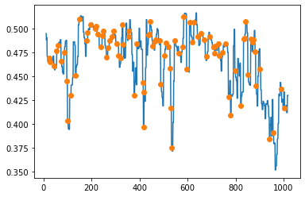

```python
find_outliers(variable='NDVI', window=12, sigma=2)
```

```python
kw = dict(window=(1, 60), variable=sorted(list(filled_sentinel.columns)), sigma=(1, 20))
i = pn.interact(find_outliers, **kw)
i.pprint()
```

```
Column
    [0] Column
        [0] Select(name='variable', options=['IBI', 'NDBI', ...], value='NDVI')
        [1] IntSlider(end=60, name='window', start=1, value=30)
        [2] IntSlider(end=20, name='sigma', start=1, value=10)
    [1] Row
        [0] Matplotlib(Figure, name='interactive00112')
```

```python
text = "<br>\n# Room Occupancy\nSelect the variable, and the time window for smoothing"

p = pn.Row(i[1][0], pn.Column(text, i[0][0], i[0][1]))
p
```

[output not shown]

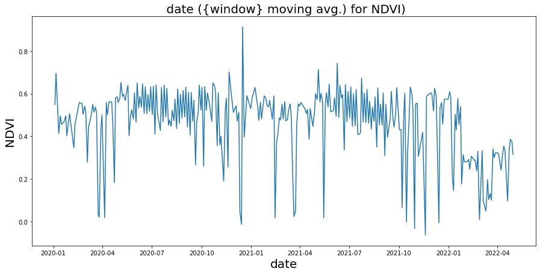

```python
#function that accepts a dataframe,the desired x and y and creates plots without any preprocessing
def create_plots_no_manipulation(data,x,y):
    fig, ax = plt.subplots(figsize=(15,7))

    # we'll plot the moving averate using ".rolling" and set a window of 12 months
    #window=11
    sns.lineplot(data=data,y=y,x=x, ax=ax)
    #sns.lineplot(data=data,y=y.rolling(window).mean(),x=x, ax=ax)
# we'll set the labels and title
    ax.set_ylabel(y,fontsize=20)
    ax.set_xlabel(x,fontsize=20)
    ax.set_title(f' '+x+' ({window} moving avg.) for '+y+')',fontsize=20);
create_plots_no_manipulation(s2_df,'date','NDVI')
```

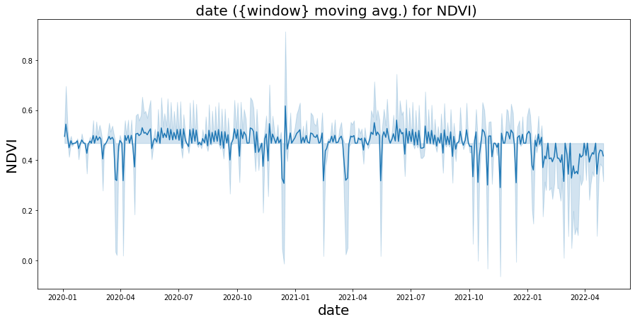

```python
#function that accepts a dataframe,the desired x and y and creates plots without any preprocessing
def create_plots_rolling(data,x,y):
    fig, ax = plt.subplots(figsize=(15,7))

    # we'll plot the moving averate using ".rolling" and set a window of 12 months
    window=len(data)
    #sns.lineplot(data=data,y=y,x=x, ax=ax)
    sns.lineplot(data=data,y=y.rolling(window).mean(),x=x, ax=ax)
# we'll set the labels and title
    ax.set_ylabel(y,fontsize=20)
    ax.set_xlabel(x,fontsize=20)
    ax.set_title(f' '+x+' ({window} moving avg.) for '+y+')',fontsize=20);
create_plots_no_manipulation(filled_sentinel,'date','NDVI')
```

```python
# function that compares two indices from the same dataset over the same x
def compare_time_series(data,x,y_1,y_2):
    series_1 = go.Scatter(
        x = data[x],
        y = data[y_1],
        mode = 'lines',
        name = str(y_1),
        line = dict(color=('rgb(244, 146, 65)'), width=2)
    )
    series_2 = go.Scatter(
        x =  data[x],
        y =  data[y_2],
        mode = 'lines',
        name = str(y_2),
        line = dict(color=('rgb(66, 244, 155)'), width=2)
    )

    d = [series_1,series_2]
    layout = dict(title = 'Comparison of '+ str(y_1) + ' and '+(y_2) + ' over ' + str(x),
                 xaxis = dict(title = 'Day number'), yaxis = dict(title = 'ndvi'))
    fig = dict(data=d, layout=layout)
    py.iplot(fig, filename='results_demonstrating0')
compare_time_series(filled_sentinel,'date','NDVI','NDBI')
```

[interactive chart not shown]

fig, ax = plt.subplots(figsize=(15,7)) # we'll plot the moving averate using ".rolling" and set a window of 12 months window=5 sns.lineplot(data=s2_df,y=s2_df['NDVI'].rolling(window).mean(),x=s2_df['date'], ax=ax) # we'll set the labels and title ax.set_ylabel('mean avg_rad',fontsize=20) ax.set_xlabel('DATE',fontsize=20) ax.set_title(f'Monthly mean blfei ({window} moving avg.) for to Jan 2020 Jan 2022)',fontsize=20);